# Introduction to Time Series Forecasting

7. Compare forecasts from stlf() with those from snaive(), using a test set comprising the last 2 years of data. Which is better?

```r
bricksq.train <- window(bricksq, end=c(1992, 3))
bricksq.test <- window(bricksq, start=c(1992, 4))
```

```r
bricksq_snaive_train <- snaive(bricksq.train)
bricksq_stlf_changing_naive_robust_train <- stlf(bricksq.train, method='naive', t.window=changing_t_window, s.window=changing_s_window, robust = TRUE)
```

**Plot snaive accuracy and residuals**

```r
accuracy(bricksq_snaive_train,bricksq.test)
```

```
##                     ME     RMSE      MAE      MPE     MAPE      MASE
## Training set  6.174825 49.71281 36.41259 1.369661 8.903098 1.0000000
## Test set     27.500000 35.05353 30.00000 5.933607 6.528845 0.8238909
##                   ACF1 Theil's U
## Training set 0.8105927        NA
## Test set     0.2405423 0.9527794
```

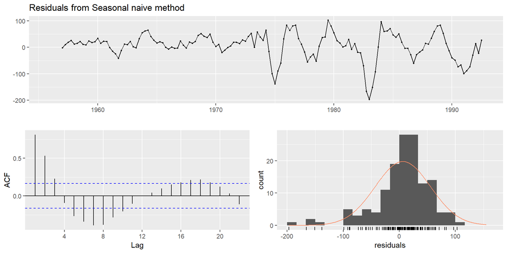

```
##
##  Ljung-Box test
##
## data:  Residuals from Seasonal naive method
## Q* = 221.45, df = 8, p-value < 2.2e-16
##
## Model df: 0.   Total lags used: 8
```

```r
checkresiduals(bricksq_snaive_train)
```

**Plot stlf accuracy and residuals**

```r
accuracy(bricksq_stlf_changing_naive_robust_train,bricksq.test)
```

```
##                     ME     RMSE      MAE       MPE     MAPE      MASE
## Training set  1.457178 21.44391 14.66609 0.3356745 3.604721 0.4027752
## Test set     26.498768 29.30314 26.49877 5.8513009 5.851301 0.7277365
##                   ACF1 Theil's U
## Training set 0.1358235        NA
## Test set     0.3824230 0.7669562
```

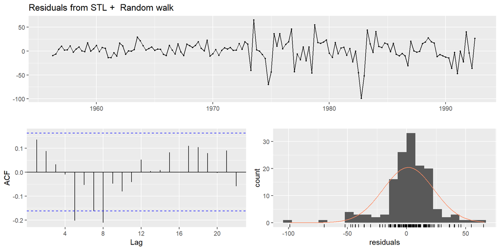

```
##
##  Ljung-Box test
##
## data:  Residuals from STL +  Random walk
## Q* = 21.797, df = 8, p-value = 0.005307
##
## Model df: 0.   Total lags used: 8
```

```r
checkresiduals(bricksq_stlf_changing_naive_robust_train)
```

# Chapter 7: Exponential Smoothing

## Question 7.5

**This question asks us to predict the next four days of book sales. We will evaluate the data, make a forecast using simple exponential smoothing, and evaluating the goodness of fit.**

Data set `books` contains the daily sales of paperback and hardcover books at the same store. The task is to forecast the next four days sales for paperback and hardcover books.

1. Plot the series and discuss the main features of the data.

**The main features of the series are that the sales of both types of books share an increasing trend. However, the paperback sales trend is leveling off more than the hardcover sales in the second half of the series. They may have different seasonalities or cycles.**

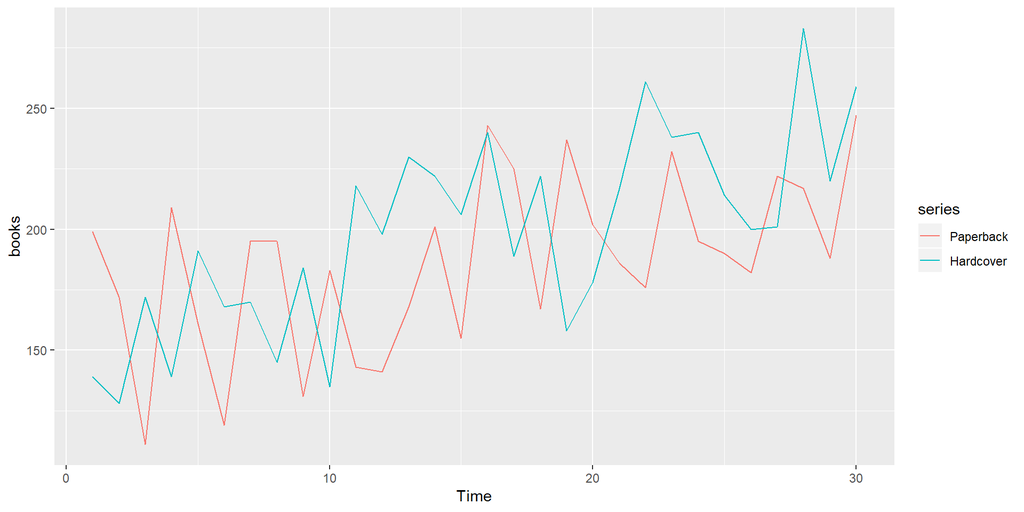

```r
autoplot(books)
```

2. Use the `ses()` function to forecast each series, and plot the forecasts.

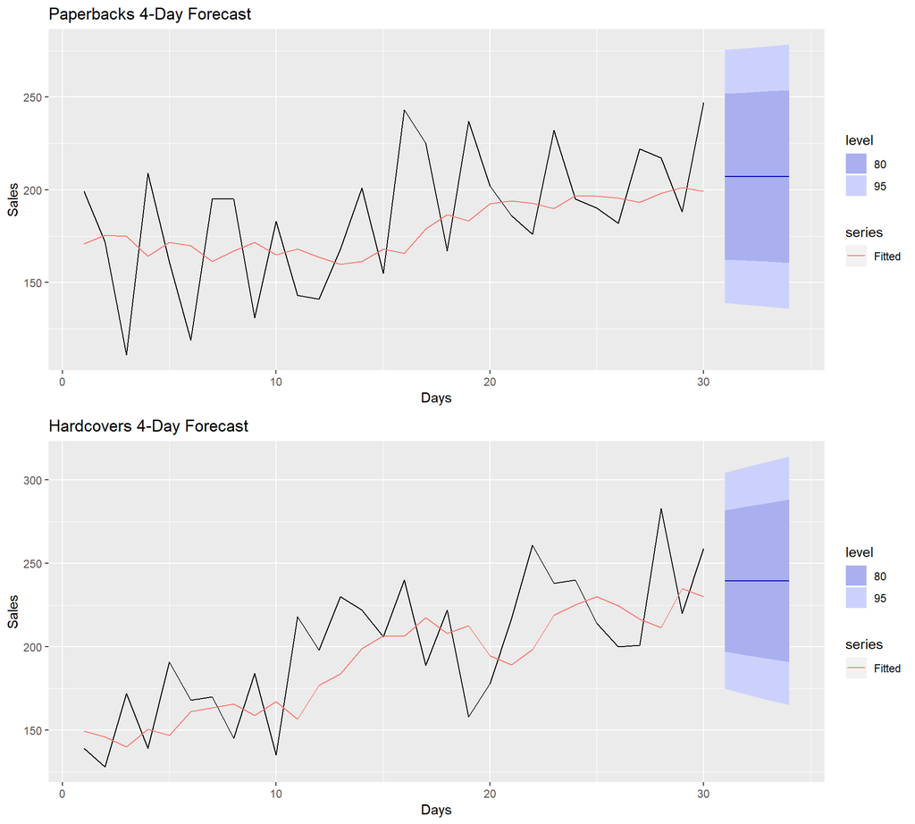

```r
paperbacks <- books[, "Paperback"]
hardcovers <- books[, "Hardcover"]

paperbacks_fc <- ses(paperbacks, h = 4)
hardcovers_fc <- ses(hardcovers, h = 4)

gridExtra::grid.arrange(
  autoplot(paperbacks_fc) +
    autolayer(fitted(paperbacks_fc), series = "Fitted") +
    ylab("Sales") + xlab("Days") + ggtitle("Paperbacks 4-Day Forecast"),
  autoplot(hardcovers_fc) +
    autolayer(fitted(hardcovers_fc), series = "Fitted") +
    ylab("Sales") + xlab("Days") + ggtitle("Hardcovers 4-Day Forecast"),
  nrow = 2
)
```

3. Compute the RMSE values for the training data in each case.

**As we would expect given the larger paperback sales confidence intervals shown above, the fit for the paperback sales has a larger root mean-squared error at 33.6 than the fit for the hardcovers at 31.9.**

```r
accuracy(paperbacks_fc)
```

```
##                    ME     RMSE     MAE       MPE     MAPE      MASE
## Training set 7.175981 33.63769 27.8431 0.4736071 15.57784 0.7021303
##                    ACF1
## Training set -0.2117522
```

```r
accuracy(hardcovers_fc)
```

```
##                    ME     RMSE      MAE      MPE     MAPE      MASE
## Training set 9.166735 31.93101 26.77319 2.636189 13.39487 0.7987887
##                    ACF1
## Training set -0.1417763
```

## Question 7.6

1. Now apply Holt’s linear method to the `paperback` and `hardback` series and compute four-day forecasts in each case.
2. Compare the RMSE measures of Holt’s method for the two series to those of simple exponential smoothing in the previous question. (Remember that Holt’s method is using one more parameter than SES.) Discuss the merits of the two forecasting methods for these data sets.
3. Compare the forecasts for the two series using both methods. Which do you think is best?
4. Calculate a 95% prediction interval for the first forecast for each series, using the RMSE values and assuming normal errors. Compare your intervals with those produced using `ses` and `holt`.

## Question 7.10

For this exercise use data set `ukcars`, the quarterly UK passenger vehicle production data from 1977Q1â“2005Q1.

1. Plot the data and describe the main features of the series. **The time series definitely appears to have a seasonality component. A little less obvious is whether there is a trend or cyclicity. While it looks like the data is trending up from 1980 to 2000, it also seems like this might be part of a larger cycle with an upturn around 1983 and a downturn around 2000.**

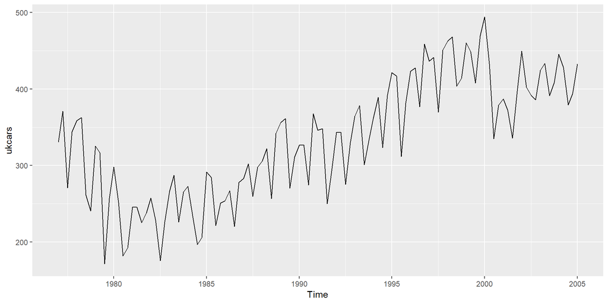

```r
autoplot(ukcars)
```

2. Decompose the series using STL and obtain the seasonally adjusted data.
3. Forecast the next two years of the series using an additive damped trend method applied to the seasonally adjusted data. (This can be done in one step using `stlf()` with arguments `etsmodel="AAN", damped=TRUE`.)
4. Forecast the next two years of the series using Holt’s linear method applied to the seasonally adjusted data (as before but with `damped=FALSE`).
5. Now use `ets()` to choose a seasonal model for the data.
6. Compare the RMSE of the ETS model with the RMSE of the models you obtained using STL decompositions. Which gives the better in-sample fits?
7. Compare the forecasts from the three approaches? Which seems most reasonable?
8. Check the residuals of your preferred model.

# Chapter 8: ARIMA Models